# Montreal R Users

## Wow session

Corey Chivers  
Data Hacker

### Welcome to the

[figure not shown]

Sponsored by:

[figure not shown]

## R does academia

Acadamic API wrappers RPLoS, Rmendeley, ROpenSci

## R does GIS

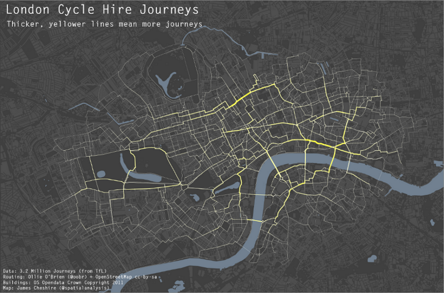

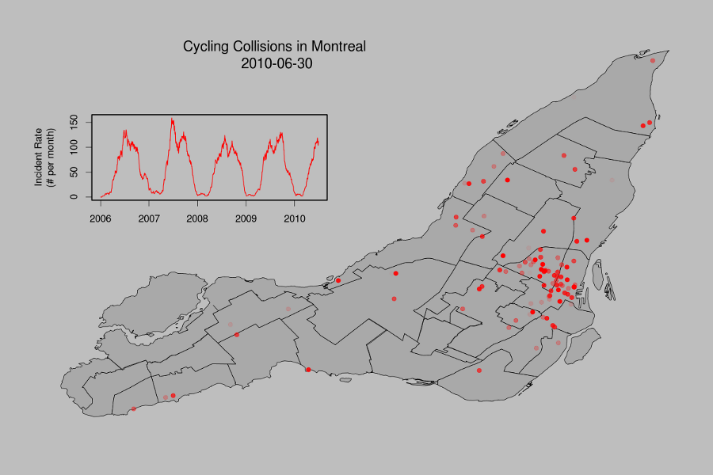

http://www.youtube.com/watch?v=hJE2_XMdfTk

## R does datamining

# Observing dark worlds Kaggle competition

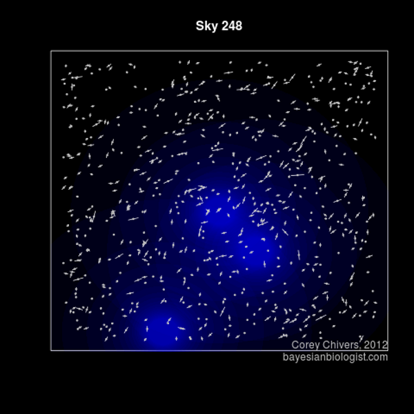

# LDA Topic modelling of the Sarah Palin Emails

- Wildlife:
  - game, fish, moose, wildlife, hunting, bears, polar, bear, subsistence, management, area, board, hunt, wolves, control, department, year, use, wolf, habitat, hunters, caribou, program, denby, fishing, …
- Energy/Fuel/Oil/Mining:
  - energy, fuel, costs, oil, alaskans, prices, cost, nome, now, high, being, home, public, power, mine, crisis, price, resource, need, community, fairbanks, rebate, use, mining, villages, …
- Trig/Family/Inspiration:
  - family, web, mail, god, son, from, congratulations, children, life, child, down, trig, baby, birth, love, you, syndrome, very, special, bless, old, husband, years, thank, best, …
- Education/Waste:
  - school, waste, education, students, schools, million, read, email, market, policy, student, year, high, news, states, program, first, report, business, management, bulletin, information, reports, 2008, quarter, …

## R does Business Intelligence

# Demand forecasting at John Deere

[figure not shown]

## R does Big Data

# R and Hadoop

# Easy parallelization and distribution

## R does journalism

New York Times Montreal Gazzette

## R does the web

[figure not shown]

https://www.facebook.com/notes/facebook-engineering/visualizing-friendships/469716398919

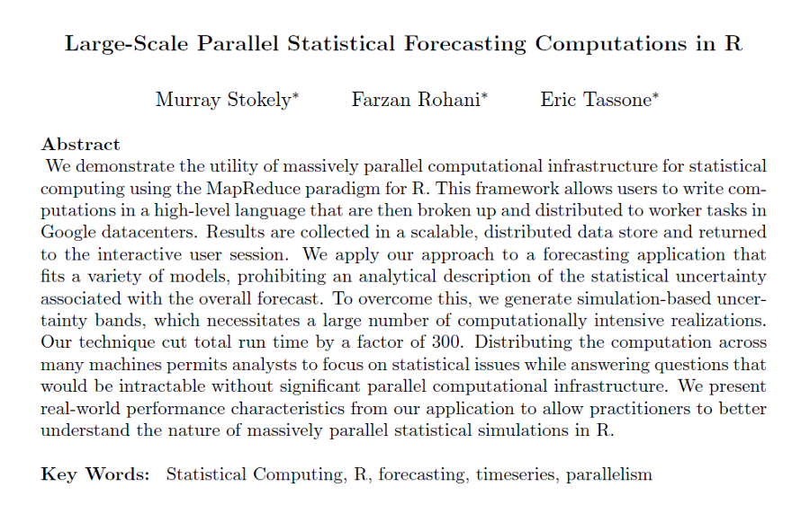

http://research.google.com/pubs/pub37483.html

Wajam

# Easy web apps with Shiny

Comapanies using R: Facebook Google linkdin

http://www.rstudio.com/shiny/

## Community development, community support

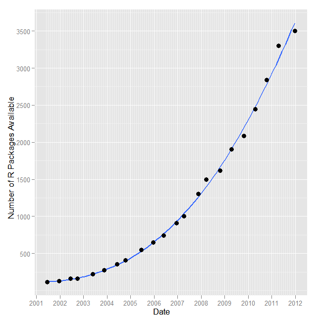

# R on stackexchange

# Code repos on github

# r-bloggers

# R mailing lists

## Some Math

```r
install_github("knitr", "yihui")
install_github("whisker", "edwindj")
install_github("markdown", "rstudio")
```

### Usage

`slidify` is designed to make it very easy for a HTML novice to generate a crisp, visually appealing `HTML5` slide deck. You can do it in just three steps!

- Write your source file in [R Markdown](http://goo.gl/KKdaf)
- Separate your slides using a horizontal rule `---`
- Run `slidify("slides.Rmd")` to generate your slide deck.

`slidify` allows you to render your slides using several HTML5 slide frameworks. Currently supported frameworks are:

- [deck.js](http://imakewebthings.com/deck.js/)
- [dzslides](http://paulrouget.com/dzslides/)
- [html5slides](http://html5slides.googlecode.com/)
- [shower](http://pepelsbey.github.com/shower/en.htm)
- slidy

Extending `slidify` to accommodate other frameworks is pretty straightforward. The plan is to support more frameworks over time.

## Thank you for hosting!

[figure not shown]